# 🚢 Titanic - Machine Learning from Disaster

# 1. Introduction

The sinking of the RMS Titanic on April 15, 1912 is one of the most infamous shipwrecks in history. Out of 2224 passengers and crew, 1502 lost their lives. While survival involved some luck, certain groups — women, children, upper-class passengers — had significantly higher survival rates. In this notebook, we'll build a machine learning model that predicts whether a passenger survived based on features like age, gender, ticket class, and family size. This is the classic Kaggle Getting Started competition, and our goal is to maximize prediction accuracy on the test set. Our approach:

Explore and visualize the data to understand survival patterns Clean the data and engineer meaningful features Train and compare multiple models Tune the best model and generate a final submission

Let's dive in!

# 2. Imports & Loading Data

```python
import pandas as pd
import numpy as np
import matplotlib.pyplot as plt
import seaborn as sns
from xgboost import XGBClassifier

sns.set_style("whitegrid")

train = pd.read_csv('data/train.csv')
test = pd.read_csv('data/test.csv')

display(train.head())
display(test.head())
print(f"Train: {train.shape}")
print(f"Test: {test.shape}")
```

|  | PassengerId | Survived | Pclass | Name | Sex | Age | SibSp | Parch | Ticket | Fare | Cabin | Embarked |
| --- | --- | --- | --- | --- | --- | --- | --- | --- | --- | --- | --- | --- |
| 0 | 1 | 0 | 3 | Braund, Mr. Owen Harris | male | 22.0 | 1 | 0 | A/5 21171 | 7.2500 | NaN | S |
| 1 | 2 | 1 | 1 | Cumings, Mrs. John Bradley (Florence Briggs Th... | female | 38.0 | 1 | 0 | PC 17599 | 71.2833 | C85 | C |
| 2 | 3 | 1 | 3 | Heikkinen, Miss. Laina | female | 26.0 | 0 | 0 | STON/O2. 3101282 | 7.9250 | NaN | S |
| 3 | 4 | 1 | 1 | Futrelle, Mrs. Jacques Heath (Lily May Peel) | female | 35.0 | 1 | 0 | 113803 | 53.1000 | C123 | S |
| 4 | 5 | 0 | 3 | Allen, Mr. William Henry | male | 35.0 | 0 | 0 | 373450 | 8.0500 | NaN | S |

|  | PassengerId | Pclass | Name | Sex | Age | SibSp | Parch | Ticket | Fare | Cabin | Embarked |
| --- | --- | --- | --- | --- | --- | --- | --- | --- | --- | --- | --- |
| 0 | 892 | 3 | Kelly, Mr. James | male | 34.5 | 0 | 0 | 330911 | 7.8292 | NaN | Q |
| 1 | 893 | 3 | Wilkes, Mrs. James (Ellen Needs) | female | 47.0 | 1 | 0 | 363272 | 7.0000 | NaN | S |
| 2 | 894 | 2 | Myles, Mr. Thomas Francis | male | 62.0 | 0 | 0 | 240276 | 9.6875 | NaN | Q |
| 3 | 895 | 3 | Wirz, Mr. Albert | male | 27.0 | 0 | 0 | 315154 | 8.6625 | NaN | S |
| 4 | 896 | 3 | Hirvonen, Mrs. Alexander (Helga E Lindqvist) | female | 22.0 | 1 | 1 | 3101298 | 12.2875 | NaN | S |

```
Train: (891, 12)
Test: (418, 11)
```

# 3. Exploratory Data Analysis (EDA)

## 3.1 Overview of the Data

```python
train.info()
```

```
<class 'pandas.DataFrame'>
RangeIndex: 891 entries, 0 to 890
Data columns (total 12 columns):
 #   Column       Non-Null Count  Dtype
---  ------       --------------  -----
 0   PassengerId  891 non-null    int64
 1   Survived     891 non-null    int64
 2   Pclass       891 non-null    int64
 3   Name         891 non-null    str
 4   Sex          891 non-null    str
 5   Age          714 non-null    float64
 6   SibSp        891 non-null    int64
 7   Parch        891 non-null    int64
 8   Ticket       891 non-null    str
 9   Fare         891 non-null    float64
 10  Cabin        204 non-null    str
 11  Embarked     889 non-null    str
dtypes: float64(2), int64(5), str(5)
memory usage: 83.7 KB
```

```python
train.describe()
```

|  | PassengerId | Survived | Pclass | Age | SibSp | Parch | Fare |
| --- | --- | --- | --- | --- | --- | --- | --- |
| count | 891.000000 | 891.000000 | 891.000000 | 714.000000 | 891.000000 | 891.000000 | 891.000000 |
| mean | 446.000000 | 0.383838 | 2.308642 | 29.699118 | 0.523008 | 0.381594 | 32.204208 |
| std | 257.353842 | 0.486592 | 0.836071 | 14.526497 | 1.102743 | 0.806057 | 49.693429 |
| min | 1.000000 | 0.000000 | 1.000000 | 0.420000 | 0.000000 | 0.000000 | 0.000000 |
| 25% | 223.500000 | 0.000000 | 2.000000 | 20.125000 | 0.000000 | 0.000000 | 7.910400 |
| 50% | 446.000000 | 0.000000 | 3.000000 | 28.000000 | 0.000000 | 0.000000 | 14.454200 |
| 75% | 668.500000 | 1.000000 | 3.000000 | 38.000000 | 1.000000 | 0.000000 | 31.000000 |
| max | 891.000000 | 1.000000 | 3.000000 | 80.000000 | 8.000000 | 6.000000 | 512.329200 |

```python
train.isnull().sum()
```

```
PassengerId      0
Survived         0
Pclass           0
Name             0
Sex              0
Age            177
SibSp            0
Parch            0
Ticket           0
Fare             0
Cabin          687
Embarked         2
dtype: int64
```

Age has 177 missing values

## 3.2 Survival Analysis

```python
train['Survived'].value_counts(normalize=True)
```

```
Survived
0    0.616162
1    0.383838
Name: proportion, dtype: float64
```

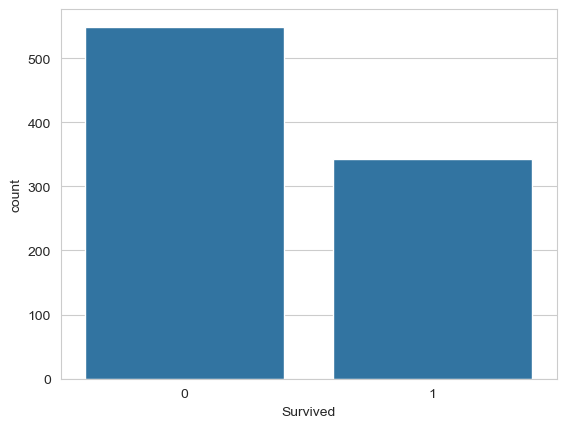

```python
sns.countplot(x = 'Survived' , data = train)
plt.show()
```

## 3.3 Feature Analysis

```
Sex     Survived
female  1           0.742038
        0           0.257962
male    0           0.811092
        1           0.188908
Name: proportion, dtype: float64
```

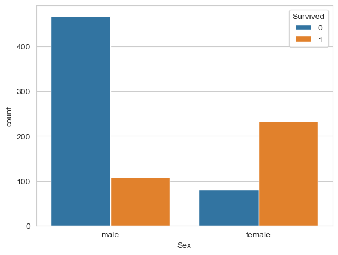

```python
print(train.groupby('Sex')['Survived'].value_counts(normalize=True))
sns.countplot(x = 'Sex', data = train , hue = 'Survived')
plt.show()
```

74% of women survived vs only 19% of men

women first actually worked

```
Pclass  Survived
1       1           0.629630
        0           0.370370
2       0           0.527174
        1           0.472826
3       0           0.757637
        1           0.242363
Name: proportion, dtype: float64
```

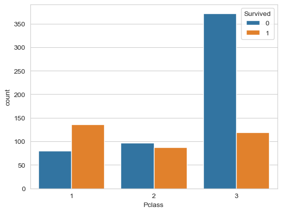

```python
print(train.groupby('Pclass')['Survived'].value_counts(normalize=True))
sns.countplot(x = 'Pclass', data = train , hue = 'Survived')
plt.show()
```

do i even need to write anything

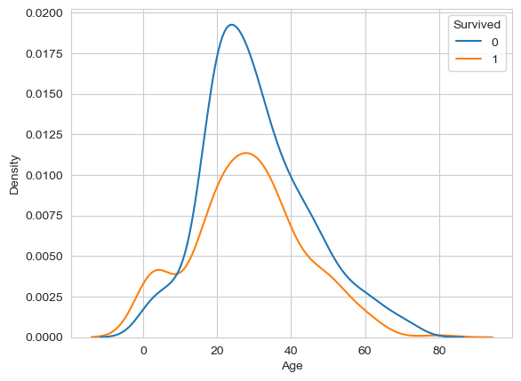

```python
sns.kdeplot(x = 'Age', data = train , hue = 'Survived')
plt.show()
```

```
Embarked  Survived
C         1           0.553571
          0           0.446429
Q         0           0.610390
          1           0.389610
S         0           0.663043
          1           0.336957
Name: proportion, dtype: float64
```

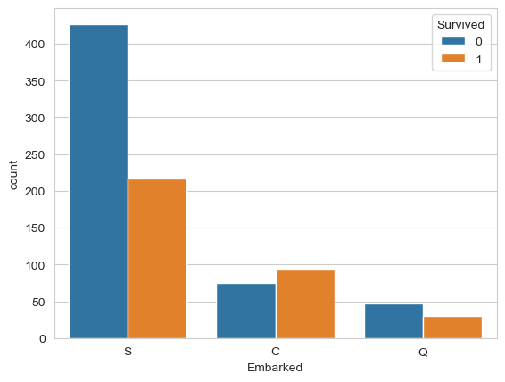

```python
print(train.groupby('Embarked')['Survived'].value_counts(normalize=True))
sns.countplot(x = 'Embarked', data = train , hue = 'Survived')
plt.show()
```

```
SibSp  Survived
0      0           0.654605
       1           0.345395
1      1           0.535885
       0           0.464115
2      0           0.535714
       1           0.464286
3      0           0.750000
       1           0.250000
4      0           0.833333
       1           0.166667
5      0           1.000000
8      0           1.000000
Name: proportion, dtype: float64
```

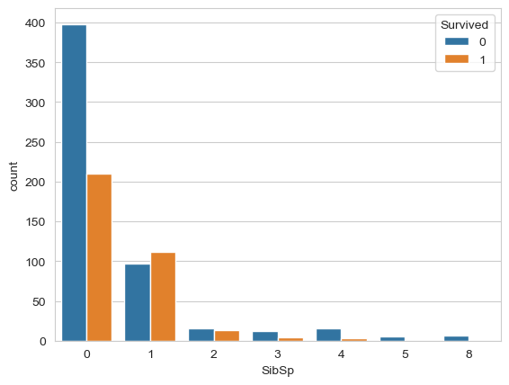

```python
print(train.groupby('SibSp')['Survived'].value_counts(normalize=True))
sns.countplot(x = 'SibSp', data = train , hue = 'Survived')
plt.show()
```

```
Parch  Survived
0      0           0.656342
       1           0.343658
1      1           0.550847
       0           0.449153
2      1           0.500000
       0           0.500000
3      1           0.600000
       0           0.400000
4      0           1.000000
5      0           0.800000
       1           0.200000
6      0           1.000000
Name: proportion, dtype: float64
```

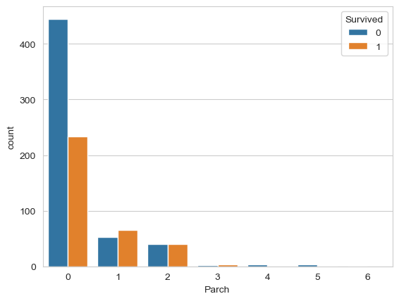

```python
print(train.groupby('Parch')['Survived'].value_counts(normalize=True))
sns.countplot(x = 'Parch', data = train , hue = 'Survived')
plt.show()
```

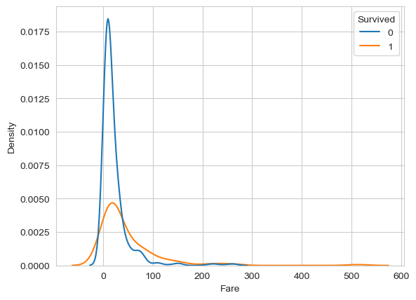

```python
sns.kdeplot(x = 'Fare', data = train , hue = 'Survived')
plt.show()
```

# 4. Data Cleaning & Preprocessing

## 4.1 Handling Missing Values

```python
train.isnull().sum()
```

```
PassengerId      0
Survived         0
Pclass           0
Name             0
Sex              0
Age            177
SibSp            0
Parch            0
Ticket           0
Fare             0
Cabin          687
Embarked         2
dtype: int64
```

```python
train['Age'] = train['Age'].fillna(train['Age'].median())
```

```python
train['Cabin'].value_counts()
```

```
Cabin
G6             4
C23 C25 C27    4
B96 B98        4
F33            3
E101           3
              ..
E17            1
A24            1
C50            1
B42            1
C148           1
Name: count, Length: 147, dtype: int64
```

```python
train.drop('Cabin', axis = 1, inplace = True)
```

```python
train.drop('PassengerId', axis = 1, inplace = True)
```

```python
train['Embarked'].fillna(train['Embarked'].mode()[0])
```

```
0      S
1      C
2      S
3      S
4      S
      ..
886    S
887    S
888    S
889    C
890    Q
Name: Embarked, Length: 891, dtype: str
```

```python
train.isnull().sum()
```

```
Survived    0
Pclass      0
Name        0
Sex         0
Age         0
SibSp       0
Parch       0
Ticket      0
Fare        0
Embarked    2
dtype: int64
```

```python
test.isnull().sum()
```

```
PassengerId      0
Pclass           0
Name             0
Sex              0
Age             86
SibSp            0
Parch            0
Ticket           0
Fare             1
Cabin          327
Embarked         0
dtype: int64
```

```python
passenger_ids = test['PassengerId']
test.drop('PassengerId', axis = 1, inplace = True)
```

```python
test['Age'] = test['Age'].fillna(test['Age'].median())
test.drop('Cabin', axis = 1, inplace = True)
```

```python
test['Fare'] = test['Fare'].fillna(test['Fare'].median())
```

```python
test.isnull().sum()
```

```
Pclass      0
Name        0
Sex         0
Age         0
SibSp       0
Parch       0
Ticket      0
Fare        0
Embarked    0
dtype: int64
```

## 4.2 Feature Engineering

```python
train['FamilySize'] = train['SibSp'] + train['Parch'] + 1
test['FamilySize'] = test['SibSp'] + test['Parch'] + 1
train['FamilySize'].value_counts()
```

```
FamilySize
1     537
2     161
3     102
4      29
6      22
5      15
7      12
11      7
8       6
Name: count, dtype: int64
```

```python
train['isAlone'] = (train['FamilySize'] == 1).astype(int)
test['isAlone'] = (test['FamilySize'] == 1).astype(int)
```

```python
train['Title'] = train['Name'].apply(lambda x: x.split(',')[1].split('.')[0].strip())
test['Title'] = test['Name'].apply(lambda x: x.split(',')[1].split('.')[0].strip())
```

```python
train['Title'].value_counts()
```

```
Title
Mr              517
Miss            182
Mrs             125
Master           40
Dr                7
Rev               6
Major             2
Mlle              2
Col               2
Don               1
Mme               1
Ms                1
Lady              1
Sir               1
Capt              1
the Countess      1
Jonkheer          1
Name: count, dtype: int64
```

```python
test['Title'].value_counts()
```

```
Title
Mr        240
Miss       78
Mrs        72
Master     21
Col         2
Rev         2
Ms          1
Dr          1
Dona        1
Name: count, dtype: int64
```

```python
test['Title'].value_counts()
```

```
Title
Mr        240
Miss       78
Mrs        72
Master     21
Col         2
Rev         2
Ms          1
Dr          1
Dona        1
Name: count, dtype: int64
```

```python
train['Title'] = train['Title'].replace(['Dr','Rev','Major','Mlle','Col','Don','Mme','Ms','Lady','Sir','Capt','the Countess','Jonkheer'],'Rare')
test['Title'] = test['Title'].replace(['Dr','Rev','Major','Mlle','Col','Don','Ms','Dona'],'Rare')
train['Title'].value_counts()
```

```
Title
Mr        517
Miss      182
Mrs       125
Master     40
Rare       27
Name: count, dtype: int64
```

```python
test['Title'].value_counts()
```

```
Title
Mr        240
Miss       78
Mrs        72
Master     21
Rare        7
Name: count, dtype: int64
```

```python
train.drop('Name', axis = 1, inplace = True)
test.drop('Name', axis = 1, inplace = True)
```

```python
train.drop('Ticket', axis = 1, inplace = True)
test.drop('Ticket', axis = 1, inplace = True)
```

## 4.3 Encoding Categorical Variables

```python
train.info()
```

```
<class 'pandas.DataFrame'>
RangeIndex: 891 entries, 0 to 890
Data columns (total 11 columns):
 #   Column      Non-Null Count  Dtype
---  ------      --------------  -----
 0   Survived    891 non-null    int64
 1   Pclass      891 non-null    int64
 2   Sex         891 non-null    str
 3   Age         891 non-null    float64
 4   SibSp       891 non-null    int64
 5   Parch       891 non-null    int64
 6   Fare        891 non-null    float64
 7   Embarked    889 non-null    str
 8   FamilySize  891 non-null    int64
 9   isAlone     891 non-null    int64
 10  Title       891 non-null    str
dtypes: float64(2), int64(6), str(3)
memory usage: 76.7 KB
```

```python
from sklearn.preprocessing import LabelEncoder
```

```python
Le = LabelEncoder()
train['Sex'] = Le.fit_transform(train['Sex'])
test['Sex'] = Le.transform(test['Sex'])
```

```python
test['Sex'].value_counts()
```

```
Sex
1    266
0    152
Name: count, dtype: int64
```

```python
train = pd.get_dummies(train, columns = ['Embarked', 'Title'], drop_first = True)
test = pd.get_dummies(test, columns = ['Embarked', 'Title'], drop_first = True)
```

```python
train.head()
```

|  | Survived | Pclass | Sex | Age | SibSp | Parch | Fare | FamilySize | isAlone | Embarked_Q | Embarked_S | Title_Miss | Title_Mr | Title_Mrs | Title_Rare |
| --- | --- | --- | --- | --- | --- | --- | --- | --- | --- | --- | --- | --- | --- | --- | --- |
| 0 | 0 | 3 | 1 | 22.0 | 1 | 0 | 7.2500 | 2 | 0 | False | True | False | True | False | False |
| 1 | 1 | 1 | 0 | 38.0 | 1 | 0 | 71.2833 | 2 | 0 | False | False | False | False | True | False |
| 2 | 1 | 3 | 0 | 26.0 | 0 | 0 | 7.9250 | 1 | 1 | False | True | True | False | False | False |
| 3 | 1 | 1 | 0 | 35.0 | 1 | 0 | 53.1000 | 2 | 0 | False | True | False | False | True | False |
| 4 | 0 | 3 | 1 | 35.0 | 0 | 0 | 8.0500 | 1 | 1 | False | True | False | True | False | False |

```python
test.head()
```

|  | Pclass | Sex | Age | SibSp | Parch | Fare | FamilySize | isAlone | Embarked_Q | Embarked_S | Title_Miss | Title_Mr | Title_Mrs | Title_Rare |
| --- | --- | --- | --- | --- | --- | --- | --- | --- | --- | --- | --- | --- | --- | --- |
| 0 | 3 | 1 | 34.5 | 0 | 0 | 7.8292 | 1 | 1 | True | False | False | True | False | False |
| 1 | 3 | 0 | 47.0 | 1 | 0 | 7.0000 | 2 | 0 | False | True | False | False | True | False |
| 2 | 2 | 1 | 62.0 | 0 | 0 | 9.6875 | 1 | 1 | True | False | False | True | False | False |
| 3 | 3 | 1 | 27.0 | 0 | 0 | 8.6625 | 1 | 1 | False | True | False | True | False | False |
| 4 | 3 | 0 | 22.0 | 1 | 1 | 12.2875 | 3 | 0 | False | True | False | False | True | False |

```python
train.info()
```

```
<class 'pandas.DataFrame'>
RangeIndex: 891 entries, 0 to 890
Data columns (total 15 columns):
 #   Column      Non-Null Count  Dtype
---  ------      --------------  -----
 0   Survived    891 non-null    int64
 1   Pclass      891 non-null    int64
 2   Sex         891 non-null    int64
 3   Age         891 non-null    float64
 4   SibSp       891 non-null    int64
 5   Parch       891 non-null    int64
 6   Fare        891 non-null    float64
 7   FamilySize  891 non-null    int64
 8   isAlone     891 non-null    int64
 9   Embarked_Q  891 non-null    bool
 10  Embarked_S  891 non-null    bool
 11  Title_Miss  891 non-null    bool
 12  Title_Mr    891 non-null    bool
 13  Title_Mrs   891 non-null    bool
 14  Title_Rare  891 non-null    bool
dtypes: bool(6), float64(2), int64(7)
memory usage: 68.0 KB
```

```python
test.info()
```

```
<class 'pandas.DataFrame'>
RangeIndex: 418 entries, 0 to 417
Data columns (total 14 columns):
 #   Column      Non-Null Count  Dtype
---  ------      --------------  -----
 0   Pclass      418 non-null    int64
 1   Sex         418 non-null    int64
 2   Age         418 non-null    float64
 3   SibSp       418 non-null    int64
 4   Parch       418 non-null    int64
 5   Fare        418 non-null    float64
 6   FamilySize  418 non-null    int64
 7   isAlone     418 non-null    int64
 8   Embarked_Q  418 non-null    bool
 9   Embarked_S  418 non-null    bool
 10  Title_Miss  418 non-null    bool
 11  Title_Mr    418 non-null    bool
 12  Title_Mrs   418 non-null    bool
 13  Title_Rare  418 non-null    bool
dtypes: bool(6), float64(2), int64(6)
memory usage: 28.7 KB
```

# 5. Model Building

## 5.1 Preparing the Data

```python
from sklearn.model_selection import train_test_split
X = train.drop('Survived', axis = 1)
y = train['Survived']
```

```python
X_train, X_test, y_train, y_test = train_test_split(X, y, test_size = 0.2, random_state = 42)
```

## 5.2 Model Training

```python
from sklearn.preprocessing import StandardScaler
from sklearn.pipeline import Pipeline
scaler = StandardScaler()
scaler.fit(X_train)
X_train_scaled = scaler.transform(X_train)
X_test_scaled = scaler.transform(X_test)
```

```python
from sklearn.linear_model import LogisticRegression
from sklearn.neighbors import KNeighborsClassifier
from sklearn.ensemble import RandomForestClassifier
from xgboost import XGBClassifier
from sklearn.metrics import accuracy_score,f1_score
```

#### Logistic Regression

```python
model = LogisticRegression()
model.fit(X_train_scaled, y_train)
y_pred = model.predict(X_test_scaled)
score_logreg = accuracy_score(y_test, y_pred)
f1_logreg = f1_score(y_test, y_pred)
print(score_logreg)
print(f1_logreg)
```

```
0.8156424581005587
0.7755102040816326
```

#### KNN

```python
model = KNeighborsClassifier()
model.fit(X_train_scaled, y_train)
y_pred = model.predict(X_test_scaled)
score_knn = accuracy_score(y_test, y_pred)
f1_knn = f1_score(y_test, y_pred)
print(score_knn)
print(f1_knn)
```

```
0.8156424581005587
0.7785234899328859
```

#### Random Forest

```python
model = RandomForestClassifier()
model.fit(X_train, y_train)
y_pred = model.predict(X_test)
score_rf = accuracy_score(y_test, y_pred)
f1_rf = f1_score(y_test, y_pred)
print(score_rf)
print(f1_rf)
```

```
0.8324022346368715
0.8026315789473685
```

#### XGBOOST

```python
model = XGBClassifier()
model.fit(X_train, y_train)
y_pred = model.predict(X_test)
score_xgb = accuracy_score(y_test, y_pred)
f1_xgb = f1_score(y_test, y_pred)
print(score_xgb)
print(f1_xgb)
```

```
0.8379888268156425
0.8
```

## 5.3 Model Comparison

```python
model_scores = {
    'f1': [f1_logreg ,f1_knn,f1_rf, f1_xgb,],
    'accuracy': [score_logreg,score_knn, score_rf, score_xgb]
}
pd.DataFrame(model_scores, index = ['LogReg', 'KNN', 'RF', 'XGB'])
```

|  | f1 | accuracy |
| --- | --- | --- |
| LogReg | 0.775510 | 0.815642 |
| KNN | 0.778523 | 0.815642 |
| RF | 0.802632 | 0.832402 |
| XGB | 0.800000 | 0.837989 |

# 6. Hyperparameter Tuning

```python
from sklearn.model_selection import GridSearchCV
```

```python
params_rf = {
    'n_estimators' : [10,50,100,200,300],
    'max_depth' : [3,5,7,10,20,None],
    'min_samples_split' : [2,5,10]
}
params_xgb = {
    'n_estimators' : [10,50,100,200,300],
    'max_depth' : [3,5,7,10,20,None],
    'learning_rate' : [0.01,0.05,0.1,0.2]
}
```

```python
grid_search = GridSearchCV(estimator = XGBClassifier(), param_grid = params_xgb,n_jobs = -1,verbose = 1)
grid_search.fit(X_train, y_train)
y_pred = grid_search.predict(X_test)
score_xgb = accuracy_score(y_test, y_pred)
f1_xgb = f1_score(y_test, y_pred)
print(score_xgb)
print(f1_xgb)
print(grid_search.best_params_)
print(grid_search.best_score_)
```

```
Fitting 5 folds for each of 120 candidates, totalling 600 fits
0.8212290502793296
0.7777777777777778
{'learning_rate': 0.1, 'max_depth': 3, 'n_estimators': 200}
0.8342263370432385
```

```python
grid_search = GridSearchCV(estimator=RandomForestClassifier(), param_grid=params_rf,n_jobs = -1,verbose = 1)
grid_search.fit(X_train, y_train)
y_pred = grid_search.predict(X_test)
score_rf = accuracy_score(y_test, y_pred)
f1_rf = f1_score(y_test, y_pred)
print(score_rf)
print(f1_rf)
print(grid_search.best_params_)
print(grid_search.best_score_)
```

```
Fitting 5 folds for each of 90 candidates, totalling 450 fits
0.8156424581005587
0.7659574468085106
{'max_depth': 5, 'min_samples_split': 5, 'n_estimators': 100}
0.8370333891460652
```

# 7. Final Prediction & Submission

```python
final_xgb = XGBClassifier( learning_rate= 0.1, max_depth = 3,n_estimators  = 200)
final_xgb.fit(X, y)
y_pred = final_xgb.predict(test)
```

```python
submission = pd.DataFrame({
    'PassengerId': passenger_ids,
    'Survived': y_pred
}).set_index('PassengerId')
```

```python
submission.head()
```

| PassengerId | Survived |
| --- | --- |
| 892 | 0 |
| 893 | 0 |
| 894 | 0 |
| 895 | 0 |
| 896 | 1 |

```python
submission.to_csv('submission.csv')
```

# 8. Conclusion

In this notebook, we built a machine learning model to predict Titanic survival using the classic Kaggle Getting Started competition. Key findings from EDA:

Gender was the strongest predictor — around 74% of women survived vs only 19% of men Passenger class mattered significantly — first class passengers had much higher survival rates Family size had an impact — solo travelers and very large families had lower survival rates

Possible improvements:

More advanced feature engineering (Age bins, Fare bins, Deck from Cabin) Trying ensemble methods like stacking or voting classifiers More sophisticated missing value imputation (grouped by Pclass and Sex) Feature selection to remove less useful features